# Neural & Behavioral Modeling - Week 13 (Exercises)

by 李彥廷 (b08207008@ntu.edu.tw)

```python
%config IPCompleter.greedy=True
%matplotlib inline
from matplotlib.pyplot import *
from IPython.display import *
import numpy as np
```

```python
# Check GPU status:
import torch as t
t.manual_seed(1)    # for reproduction
print('PyTorch version:',t.__version__)
use_cuda=t.cuda.is_available()
if(use_cuda):
    for i in range(t.cuda.device_count()):
        print('Device ',i,':',t.cuda.get_device_name(i))
    print('Current: Device ',t.cuda.current_device())
    t.backends.cudnn.benchmark = True
    device = t.device("cuda")
else:
    device = t.device("cpu")
    print('No GPU')
```

```
PyTorch version: 1.12.1+cu113
Device  0 : Tesla T4
Current: Device  0
```

## 1 Visualizing the latent space of an autoencoder (4 points)

Please train an autoencoder to project MNIST (training) images to a 2D latent space and visualize how these images are organzed in the latent space, as demonstrated in P.20 of model_13_slides.pdf.

[figure not shown]

### 1.0 The MNIST Data

```python
# Download the dataset:
import urllib.request
urllib.request.urlretrieve('https://github.com/mnielsen/neural-networks-and-deep-learning/raw/master/data/mnist.pkl.gz','mnist.pkl.gz')
```

```
('mnist.pkl.gz', <http.client.HTTPMessage at 0x7f802032edf0>)
```

```python
# Load the dataset:
import pickle, gzip
f = gzip.open('mnist.pkl.gz','rb')
train_set, valid_set, test_set = pickle.load(f,encoding='unicode-escape')
f.close()
x_train,y_train=train_set[0],train_set[1]
x_valid,y_valid=valid_set[0],valid_set[1]
x_test,y_test=test_set[0],test_set[1]

# Transform NumPy arrays to PyTorch tensors:
use_cuda=t.cuda.is_available()

X_train=t.from_numpy(x_train)
Y_train=t.from_numpy(y_train)
X_valid=t.from_numpy(x_valid)
Y_valid=t.from_numpy(y_valid)
X_test=t.from_numpy(x_test)
Y_test=t.from_numpy(y_test)

if(use_cuda):
    print('use cuda')
    X_train=X_train.cuda()
    Y_train=Y_train.cuda()
    X_valid=X_valid.cuda()
    Y_valid=Y_valid.cuda()
    X_test=X_test.cuda()
    Y_test=Y_test.cuda()
```

```
use cuda
```

```
(50000, 784) (50000,) (10000, 784) (10000,)
0.0 0.99609375 0 9
```

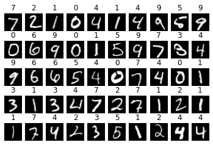

```python
# Examine the dataset:
print(x_train.shape,y_train.shape,x_test.shape,y_test.shape)
print(np.min(x_train),np.max(x_train),np.min(y_train),np.max(y_train))
for i in range(50):
    subplot(5,10,i+1)
    imshow(x_test[i].reshape([28,28]),cmap='gray');
    title(str(y_test[i]));
    axis('off')
```

### 1.1 An autoencoder

```python
import torch.nn as nn

# Define the network:
class autoencoder(nn.Module):
    def __init__(self):
        super(autoencoder, self).__init__()

        self.encoder = nn.Sequential(
            nn.Linear(28*28, 128),
            nn.ReLU(True),
            nn.Linear(128, 64),
            nn.ReLU(True),
            nn.Linear(64, 12),
            nn.ReLU(True),
            nn.Linear(12, 2) # 2-dimensional latent space
        )

        self.decoder = nn.Sequential(
            nn.Linear(2, 12),
            nn.ReLU(True),
            nn.Linear(12, 64),
            nn.ReLU(True),
            nn.Linear(64, 128),
            nn.ReLU(True),
            nn.Linear(128, 28*28),
            nn.Tanh()
        )

    def forward(self, x):
        encode = self.encoder(x)
        decode = self.decoder(encode)
        return encode, decode
```

```python
model=autoencoder()
print(model)
loss_fn = t.nn.MSELoss()
learning_rate = 1e-3
optimizer = t.optim.Adam(model.parameters(), lr=learning_rate) #https://pytorch.org/docs/stable/optim.html

if(use_cuda):
    model=model.cuda()
    loss_fn=loss_fn.cuda()
```

```
autoencoder(
  (encoder): Sequential(
    (0): Linear(in_features=784, out_features=128, bias=True)
    (1): ReLU(inplace=True)
    (2): Linear(in_features=128, out_features=64, bias=True)
    (3): ReLU(inplace=True)
    (4): Linear(in_features=64, out_features=12, bias=True)
    (5): ReLU(inplace=True)
    (6): Linear(in_features=12, out_features=2, bias=True)
  )
  (decoder): Sequential(
    (0): Linear(in_features=2, out_features=12, bias=True)
    (1): ReLU(inplace=True)
    (2): Linear(in_features=12, out_features=64, bias=True)
    (3): ReLU(inplace=True)
    (4): Linear(in_features=64, out_features=128, bias=True)
    (5): ReLU(inplace=True)
    (6): Linear(in_features=128, out_features=784, bias=True)
    (7): Tanh()
  )
)
```

### 1.2 Your training (2 points)

```python
# Specify batch size
batch_size = 1000
iterations = int(len(X_train)/batch_size)
epoch = 150

# Split the training data
for i in range(epoch):
    # shuffle batches
    randperm = t.randperm(X_train.size()[0])
    X_train_r = X_train[randperm]
    X_train_batches = X_train_r.reshape(iterations, batch_size, -1)
    # Y_train_batches = Y_train.reshape(n_batch, batch_size)
    for batch in range(iterations):
        # Forward pass:
        encode, decode = model(X_train_batches[batch])
        loss = loss_fn(X_train_batches[batch], decode)

        # Zero the gradients before running the backward pass.
        model.zero_grad()

        # Backward pass:
        loss.backward()

        # Update the weights using gradient descent:
        optimizer.step()
```

```
Original Image:
```

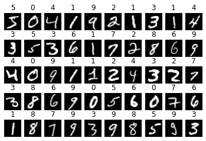

```
Decode Result:
```

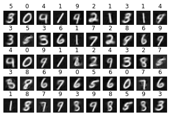

```python
# Check training accuracy:
encode, decode = model(X_train[:100])
decode = decode.cpu().detach().numpy()

print('Original Image:')
X_trains = X_train.cpu().detach().numpy()
fig, pltlist = subplots(5,10)
pltlist = pltlist.flatten()
for i in range(50):
    pltlist[i].imshow(X_trains[i].reshape([28,28]),cmap='gray');
    pltlist[i].set_title(str(y_train[i]));
    pltlist[i].axis('off')
show()
print()
print('Decode Result:')
for i in range(50):
    subplot(5,10,i+1)
    imshow(decode[i].reshape([28,28]),cmap='gray');
    title(str(y_train[i]));
    axis('off')
```

### 1.3 Your visualization (2 points)

```python
x, y = np.meshgrid(np.arange(-2.5,5.5,.3),np.arange(-15,0.5,1))
print(x.shape)
```

```
(16, 27)
```

```python
encode, decode = model(X_train)
encode = encode.cpu().detach().numpy()
decode = decode.cpu().detach().numpy()
imgList=[]
x, y = np.meshgrid(np.arange(-2.5,5.5,.3),np.arange(-15,0.5,0.9))
row = x.shape[0]
col = x.shape[1]
x = x.flatten()
y = y.flatten()[::-1]

for i in range(len(x)):
    point = t.FloatTensor([x[i],y[i]])
    if(use_cuda):
        point = point.cuda()
    img = model.decoder(point)
    img = img.cpu().detach().numpy()
    imgList.append(img)
```

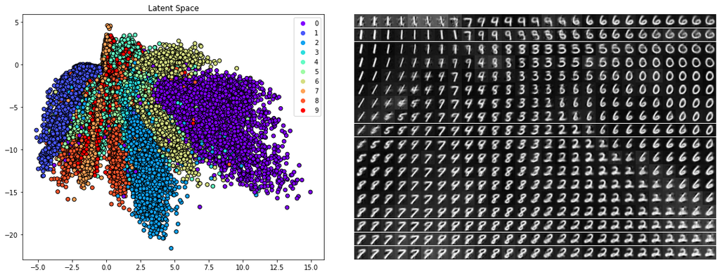

```python
fig = figure(figsize=(13,7))
gs1 = GridSpec(1, 1, left = 0, right = 0.5)
ax1 = fig.add_subplot(gs1[0, 0])
sca = ax1.scatter(encode[:,0], encode[:,1], c=y_train, cmap='rainbow', edgecolor='black')
ax1.set_title('Latent Space')
legend(handles=sca.legend_elements()[0], labels=[0,1,2,3,4,5,6,7,8,9])


gs2 = GridSpec(row, col, left = 0.55, right = 1.15, wspace=0.0, hspace=0.0)
cut = max(row,col)
for i in range(len(x)):
    img = imgList[i]
    ax = fig.add_subplot(gs2[i//cut, i%cut])
    ax.imshow(img.reshape([28,28]),cmap='gray');
    axis('off')
```

## 2 Integer Factorization (4 points)

Here we explore the possibilty that a neural network may be able to judge whether an input integer is a prime number or not.

- Computational problem: tell if an input is a prime number
- Network Input: an integer in binary code (e.g., 0→000000000000000 (15 bits); 1→000000000000001; 2→000000000000010)
- Network Output: 1 unit (1=yes; 0=no)
- Network Architecture: your choice
- Data set: You can enlarge your training and testing data sets, if necessary. Training accuracies and testing accuraces are both informative but of course we care more about the testing ones.

### 2.1 The data set

```python
from math import sqrt; from itertools import count, islice

def isPrime(n):
    return n > 1 and all(n%i for i in islice(count(2), int(sqrt(n)-1)))

ifPrime=np.vectorize(isPrime)

x=np.arange(32768) #2^15
y=ifPrime(x).astype(int)

# Training-testing splits:

from sklearn.model_selection import train_test_split
newx = []
for i in range(len(x)):
    newx.append(list(format(x[i], '015b')))
newx = np.array(newx, dtype='int')
x_train, x_test, y_train, y_test = train_test_split(newx, y, test_size=0.20)

# Training data:
print(x_train.shape,x_train)
print(y_train.shape,y_train)

# Testing data:
print(x_test.shape,x_train)
print(y_test.shape,y_train)
```

```
(26214, 15) [[0 1 1 ... 0 1 0]
 [1 0 0 ... 1 0 1]
 [0 0 1 ... 1 0 1]
 ...
 [1 0 0 ... 1 0 1]
 [0 1 1 ... 0 1 0]
 [1 0 1 ... 1 1 1]]
(26214,) [0 0 0 ... 1 0 1]
(6554, 15) [[0 1 1 ... 0 1 0]
 [1 0 0 ... 1 0 1]
 [0 0 1 ... 1 0 1]
 ...
 [1 0 0 ... 1 0 1]
 [0 1 1 ... 0 1 0]
 [1 0 1 ... 1 1 1]]
(6554,) [0 0 0 ... 1 0 1]
```

### 2.2 Your computational experiments (2 points)

```python
# Transform NumPy arrays to PyTorch tensors:
use_cuda=t.cuda.is_available()

X_train=t.from_numpy(x_train)
Y_train=t.from_numpy(y_train)
X_test=t.from_numpy(x_test)
Y_test=t.from_numpy(y_test)

if(use_cuda):
    X_train=X_train.cuda()
    Y_train=Y_train.cuda()
    X_test=X_test.cuda()
    Y_test=Y_test.cuda()
```

```python
# Please train & evaluate your model here.
# Here is the PyTorch net:

D_in,H,D_out=15,100,2

# Training the network:
model = t.nn.Sequential(
    t.nn.Linear(D_in, H),
    t.nn.BatchNorm1d(H),
    t.nn.ReLU(),
    t.nn.Dropout(p=0.2),
    t.nn.Linear(H, H),
    t.nn.BatchNorm1d(H),
    t.nn.ReLU(),
    t.nn.Dropout(p=0.2),
    t.nn.Linear(H, D_out),
    t.nn.Softmax(dim=1)
)

loss_fn = t.nn.CrossEntropyLoss()
learning_rate = 1e-3
optimizer = t.optim.Adam(model.parameters(), lr=learning_rate) #https://pytorch.org/docs/stable/optim.html

if(use_cuda):
    model=model.cuda()
    loss_fn=loss_fn.cuda()


# Specify batch size
batch_size = 1024
iterations = int(len(X_train)/batch_size)
epoch = 150

# Split the training data
for i in range(epoch):
    # shuffle batches
    randperm = t.randperm(X_train.size()[0])
    X_train_r = X_train[randperm][:batch_size*iterations]
    Y_train_r = Y_train[randperm][:batch_size*iterations]
    X_train_batches = X_train_r.reshape(iterations, batch_size, -1)
    Y_train_batches = Y_train_r.reshape(iterations, batch_size)
    # Y_train_batches = Y_train.reshape(n_batch, batch_size)
    for batch in range(iterations):
        # Forward pass:
        Y_pred = model(X_train_batches[batch].float())
        loss = loss_fn(Y_pred, Y_train_batches[batch])

        # Zero the gradients before running the backward pass.
        model.zero_grad()

        # Backward pass:
        loss.backward()

        # Update the weights using gradient descent:
        optimizer.step()

    # Check training accuracy:
    if i % 10 == 0:
        Y_pred = model(X_train.float()) # Y_pred.shape=[50000,10]
        Y_pred = t.max(Y_pred,1)[1] # Y_pred.shape=[50000]
        print('epoch ',i,':',(Y_pred==Y_train).sum().item()/Y_train.shape[0])
```

```
epoch  0 : 0.8908979934386206
epoch  10 : 0.8908979934386206
epoch  20 : 0.8908979934386206
epoch  30 : 0.8910887312123293
epoch  40 : 0.8912031738765546
epoch  50 : 0.8916227969787137
epoch  60 : 0.8927290760662242
epoch  70 : 0.8931486991683834
epoch  80 : 0.8954375524528878
epoch  90 : 0.895551995117113
epoch  100 : 0.8973830777447166
epoch  110 : 0.8979934386205844
epoch  120 : 0.8981460288395514
epoch  130 : 0.9001297016861219
epoch  140 : 0.8999008163576715
```

```python
# validation set
Y_pred = model(X_test.float())
Y_pred = t.max(Y_pred,1)[1]
print('validation set accuracy:',(Y_pred==Y_test).sum().item()/Y_test.shape[0])
```

```
validation set accuracy: 0.8954836740921575
```

### 2.3 Your discussion (2 points)

```python
# Please explain why your model prediction accuracy is better than chance but worse than perfect.
Y_pred = model(X_test.float())
Y_pred = t.max(Y_pred,1)[1]
nums = np.random.randint(len(X_test), size=20)
primeList = []
primePred = []
for i in range(len(Y_test)):
    if Y_test[i] == 1:
        prime = ''.join(X_test[i].cpu().detach().numpy().astype('str'))
        primeList.append(int(prime,2))
        primePred.append(Y_pred[i].cpu().detach().numpy())
print('{:>5}  {:>5}  {:>5}'.format('Number', 'isPrime', 'Prediction'))
print('----------------------------')
for num in nums:
    thisX = ''.join(X_test[num].cpu().detach().numpy().astype('str'))
    line_new = '{:>6}  {:>7}  {:>10}'.format(int(thisX, 2), Y_test[num], Y_pred[num])
    print(line_new)
```

```
Number  isPrime  Prediction
----------------------------
 10178        0           0
  3668        0           0
  9990        0           0
 31579        0           0
 15391        1           0
 18700        0           0
 24447        0           0
 27545        0           0
 19608        0           0
 32467        1           0
  2565        0           0
  6253        0           0
 19628        0           0
 25804        0           0
 15874        0           0
 11368        0           0
  9023        0           0
 24816        0           0
 21468        0           0
  9187        1           0
```

```python
print('數字總數:',len(x))
print('質數總數:',sum(y))
print('質數比例:',sum(y)/len(x))
```

```
數字總數: 32768
質數總數: 3512
質數比例: 0.107177734375
```

```python
print('Testing Data')
print('質數數量:', len(primeList))
print('預測正確的質數:', sum(primePred))
print('質數預測正確率:', sum(primePred)/len(primeList))
```

```
Testing Data
質數數量: 652
預測正確的質數: 26
質數預測正確率: 0.03987730061349693
```

我認為這個模型看似可以預測質數是因為質數太少，有imbalance categories的問題。 從上面的結果可以看出這個模型在質數testing data的預測正確率上僅有0.039左右。而九成的正確率主要來自非質數的預測結果，模型就算全部都選擇非質數也能在測試資料上達到約九成的正確率